# A Theoretical Foundation for the Age-Area Hypothesis

## Matthew J. Baker

## Hunter College and the Graduate Center, CUNY

## March 16, 2016

# Motivation and Overview

- Research on Indigenous peoples and the economics of culture and institutions.
- How and why do cultural practices, customary norms, etc. change and evolve over time?

# Previous work:

- Nature of Land Tenure [(Baker, 2003)](https://ideas.repec.org/a/ucp/jpolec/v111y2003i1p124-173.html)
- Post-marital residence [(Baker and Jacobsen, 2007a)](https://ideas.repec.org/a/oup/jleorg/v23y2007i1p208-241.html)
- Land inheritance [(Baker and Miceli, 2005)](https://ideas.repec.org/a/eee/jeborg/v56y2005i1p77-102.html)
- Origins of Agriculture [(Baker, 2008)](https://ideas.repec.org/a/kap/jecgro/v13y2008i4p257-292.html)
- Marriage and the Division of Labor [(Baker and Jacobsen, 2007b)](https://ideas.repec.org/a/ucp/jlabec/v25y2007p763-793.html)
- Hierarchy and Governance [(Baker, Bulte, and Weisdorf, 2010)](https://ideas.repec.org/a/cup/jinsec/v6y2010i02p215-242_99.html)

*Behavioral Ecology* - Theories of how environment and/or technology drive cultural evolution and change.

# Theories need tests

How could one devise a formal test of such theories?

One possibility is *Cross-Cultural Data* - Data comprised of a list of different societies, along with:

- Technological information
- Environmental information
- Information on culture pratices and institutions

**Anthropological tradition** - [The comparative method](http://anthropology.ua.edu/cultures/cultures.php?culture=Cross-Cultural%20Analysis)

# Prominent Examples:

## SCCS (Standard Cross-Cultural Sample)

## Ethographic Atlas

Essentially, the work of George Murdock, Douglas White - and a lot of students. An example:

```python
Data.rename(columns = {'eaName':'EAname', 'ruhlen_1': 'phylum', 'v1':'hunt', 'v2':'gather',
                       'v3':'fish', 'v4':'farm', 'v5':'herd', 'v6':'Mar',
                       'v35': 'games', 'v71': 'slavery'}, inplace=True)
Data[['EAname','phylum','lat','lon','hunt','gather','fish','farm','herd','Mar',
                      'games','slavery']].iloc[0:10]
```

|  | EAname | phylum | lat | lon | hunt | gather | fish | farm | herd | Mar | games | slavery |
| --- | --- | --- | --- | --- | --- | --- | --- | --- | --- | --- | --- | --- |
| 0 | KUNG | KHOISAN | -19.00 | 21.00 | 8 | 2 | 0 | 0 | 0 | 2 | 2 | 1 |
| 1 | WARRAU | AMERIND | 9.33 | -61.67 | 8 | 2 | 0 | 0 | 0 | 2 | 2 | 1 |
| 2 | KUNG | KHOISAN | -19.67 | 18.00 | 8 | 2 | 0 | 0 | 0 | 2 | 2 | 1 |
| 3 | SWAZI | NIGER... | -26.50 | 31.00 | 1 | 1 | 0 | 2 | 6 | 1 | 0 | 1 |
| 4 | PENDE | NIGER... | 4.00 | 18.50 | 1 | 0 | 1 | 2 | 6 | 3 | 0 | 2 |
| 5 | BAJUN | NIGER... | -6.50 | 39.00 | 0 | 1 | 4 | 1 | 4 | 1 | 0 | 2 |
| 6 | NYORO | NIGER... | 0.50 | 30.50 | 0 | 1 | 1 | 2 | 6 | 1 | 6 | 2 |
| 7 | KPE | NIGER... | 7.00 | -10.00 | 0 | 1 | 1 | 3 | 5 | 1 | 0 | 2 |
| 9 | FON | NIGER... | 6.42 | 2.17 | 0 | 2 | 1 | 2 | 5 | 1 | 8 | 1 |
| 10 | KISSI | NIGER... | 9.06 | -10.18 | 0 | 0 | 0 | 1 | 8 | 1 | 0 | 2 |

# Difficulties

As recognized by Galton's reaction to Edward Tylor's work in 1888 ([Galton's Problem](https://en.wikipedia.org/wiki/Galton%27s_problem)): Usual statistical independence assumptions completely break down:

- Spatial dependence - borrowing and learning
- Historical dependence - common ancestry
- Second-order Spatial and Historical dependence

Versions of this problem in economics: [Manski's (1993)](http://www.jstor.org/stable/2298123?seq=1#page_scan_tab_contents) **reflection problem**, Spatial Econometrics [(Lesage's, 1999)](http://www.spatial-econometrics.com/html/sbook.pdf).

# Demonstration (1 of 3): Marriage

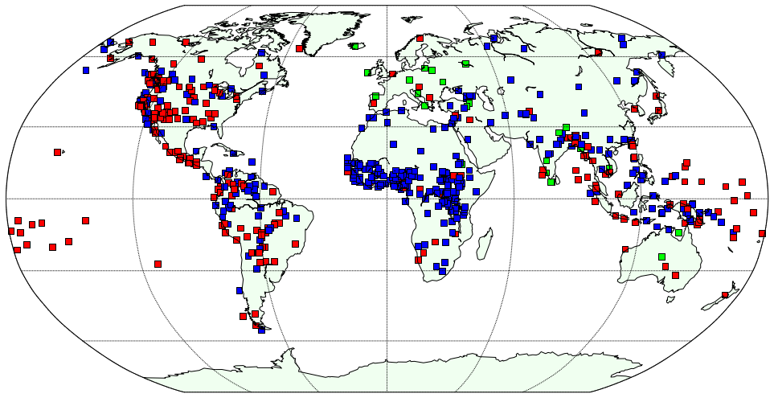

```python
Image(filename='IEMaps\\WorldMarriageMap1.png')
```

# Demonstration (2 of 3): Marriage and Agriculture

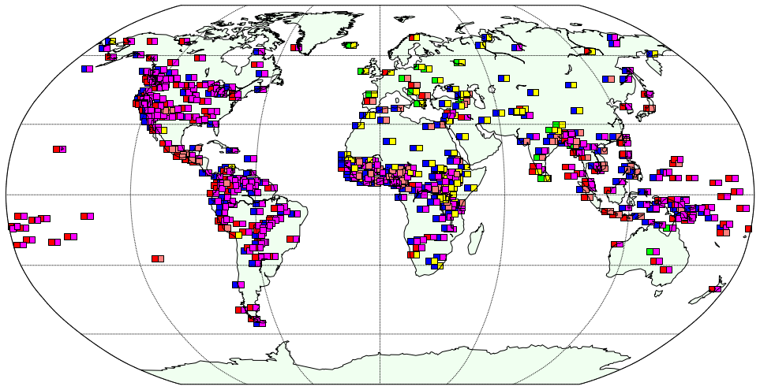

```python
Image(filename='IEMaps\\WorldMarriageMap2.png')
```

# Demonstration (3 of 3): Marriage and Language Phylum

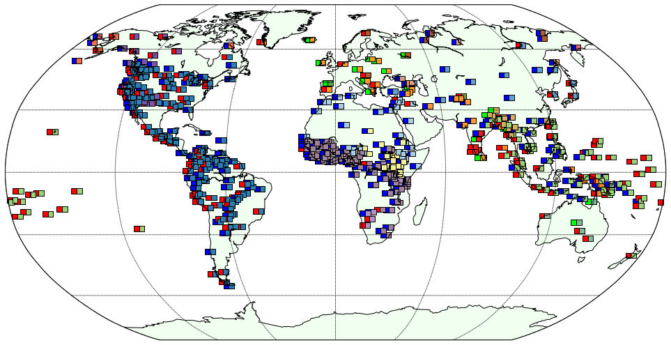

```python
Image(filename='IEMaps\\WorldMarriageMap3.png')
```

# Some Developments:

Over past 20 years:

- Bayesian and simulation-based methods make estimation of almost anything possible
- Developments in computational linguistics - maximum likelihood methods on phylogenies as in genetics. Realization that languages can function as a sort of genetic code.
- Accessability - vast amount of tools and computing power readily available. Very flexible languages (Python)
- Tenure

## My Thought -

In principle, it is possible to recover distributions over past histories (which peoples were where, when). Then: what can be known about horizontal, vertical, technological, and ecological "causes" of cultural practices?

# Current Paper and Research

A part of the research agenda - distributions over past locations. **How can one use phylogenetic information to assign locations and times to different groups?**

**Key Component** Mathematical modelling of the likely locations of groups and peoples at particular times.

# Point of Departure: *The Age-Area Hypothesis*

"...the area that has the greatest diversity...is likely to be the location of the original homeland...In saying this, we are assuming the lowest number of population movements to account for the geographical distribution of the subgroups..." Crowley and Bowern, 2010, p. 313

Somewhat imprecisely stated - [Merritt Ruhlen's](http://www.amazon.com/The-Origin-Language-Tracing-Evolution/dp/0471159638) variation is point of origin is where the *most divergent* language is - he credits it to [Edward Sapir](https://en.wikipedia.org/wiki/Edward_Sapir).

# Basis for the AAH?

## (Anthropological) Age-Area Hypothesis

Attributed to [Clark Wissler](https://en.wikipedia.org/wiki/Clark_Wissler#cite_note-Clark_Wissler_1999-3)- age of a cultural practice proportional to the breadth of its geographical distribution. Language a special case?

## Maximum genetic diversity

Maximum *genetic* diversity occurs at the point of origin. A fact used to [support modern humans' origins in Africa](http://www.sciencedaily.com/releases/2009/04/090430144524.htm). Why? A sub-population is [not as diverse as the entire population](http://www.sciencedaily.com/releases/2007/07/070718140829.htm).

# Questions and comments:

- Minimum population movements does not by itself imply **AAH**, but suggests a plan of attack.
- The analogy with population biology does not work...People don't migrate with a fraction of language vocabularly.
- Lack of precision in statements like "likely."

# Examples

## Rooted Tree with Five Groups

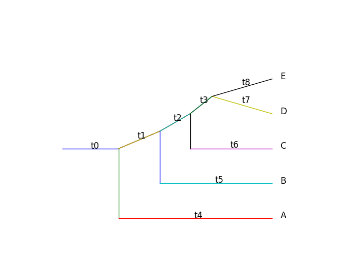

```python
Image(filename='Writeup\\figure1.png')
```

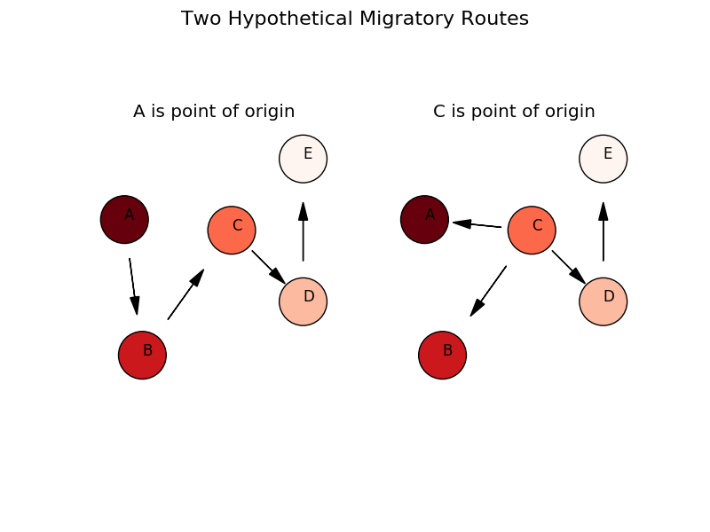

```python
Image(filename='Writeup\\figure2.png')
```

The age-area hypothesis suggests that the origins of this group should be at point $A$, and that the more likely sequence of events is to the left. If we apply the AAH recursively, we find that the migratory route should be $A$ to $B$ to $C$ to $D$ or $E$...

**Note**: minimum moves only restrict things to observed locations.

# Example: Na-Dene

As another example, let's look at the **Na-Dene** language tree (really, an example of one such tree that is not exactly anatomically correct). Includes languages such as Apache, Navajo, Tlingit, and Chipewyan. Locations:

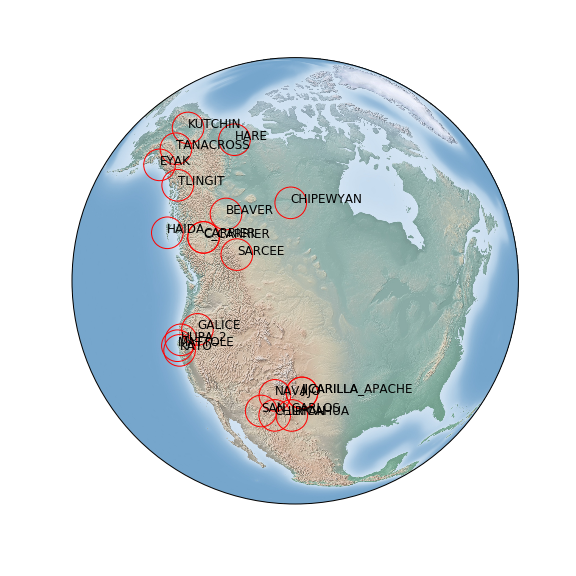

```python
Image(filename='IEMaps\\NaDeneLocs.png')
```

# Na-Dene Phylogenetic Tree (again, not quite right)

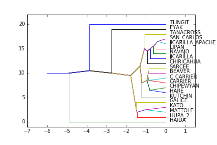

```python
Image(filename='IEMaps\\ExNaDeneTree.png')
```

## Age-Area hypothesis suggests something like:

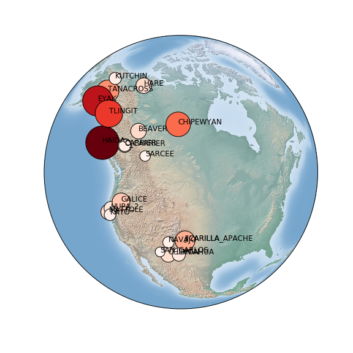

```python
Image(filename='IEMaps\\NaDeneWLocs.png')
```

# Building a Theory

## Back to my example:

Why would one think that the events starting at $A$ is more likely? Occam's razor-like belief that this is simpler than the events starting at $C$ or any other point. More technically, this explanation *conserves migratory events*.

In some sense, we only need one migratory sequence to explain things in the $A$-based scenario.

Question: how can this be made operational in terms of mathematics? Precedent: models associating least-cost algorithms (parsimony) to likelihood. [Felsenstein (2004)](http://www.amazon.com/Inferring-Phylogenies-Joseph-Felsenstein/dp/0878931775).

# Underpinnings of a Model - basic assumptions

1. Migrations occur as random jumps.
2. Within a given sequence of migrations, jumps arrive according to a migratory-event-specific distribution.
3. Once a jump has occurred from a location, the location goes dormant - subsequent migrations from this location require introduction of a new migratory sequence.

# Narrowing assumptions:

1. Within a given migratory sequence, jumps occur through time according to an exponential distribution. *The parameter $\lambda$ is specific to the sequence*.
2. Migrations are teleportations - ignore time and distance spent migrating for now (I use distance to resolve ties in my implementation).

# Likelihood Comparison

## Migration starting at A:

$ P(A;\lambda) = \lambda e^{-\lambda t_0}\lambda e^{-\lambda t_1} \lambda e^{-\lambda t_2} \lambda e^{-\lambda t_3} e^{-\lambda t_8} = \lambda^4 e^{-\lambda( t_0+ t_1+ t_2+ t_3 +t_8)} $

## Migration starting at C:

$ P(C;\lambda_1, \lambda_2, \lambda_3) = \lambda_1 e^{-\lambda_1 (t_0+t_4)}\lambda_2 e^{-\lambda_2 (t_1+t_5)} \lambda_3 e^{-\lambda t_2} \lambda_3 e^{-\lambda t_3} e^{-\lambda_3 t_8} = \lambda_1 e^{-\lambda_1 (t_0+t_4)}\lambda_2 e^{-\lambda_2 (t_1+t_5)} \lambda^2_3 e^{-\lambda_2( t_2+ t_3+ t_8)} $

# In Logs:

## A:

$ LL_(A;\lambda) = 4 \ln \lambda-\lambda( t_0+ t_1+ t_2+ t_3 +t_8) $

## B:

$ LL_(B;\lambda_1,\lambda_2,\lambda_3) = \ln \lambda_1 -\lambda_1 (t_0+t_4) + \ln \lambda_2 -\lambda_2 (t_1+t_5) - 2 \ln \lambda_3 -\lambda_2( t_2+ t_3+ t_8) $

Maximum likelihood estimate of $\lambda$ is:

$ \lambda^* = \frac{n}{\sum_{i=1}^n t_i} $

# Maximized w.r.t. Parameters:

$ LL_A = 4 (\ln 4 - 1) - 4 \ln (t_0+ t_1+ t_2+ t_3 +t_8) $

$ LL_C = 2 (\ln 2 - 2) - \ln (t_0 + t_4) - \ln (t_1 +t _5) - 2 \ln (t_2+t_3+t_8) $

**Likelihood of each route being "the" route.**

Suppose that $\Delta$ is the size of a unit of time, with $ \Delta = \delta T$, and $\delta = \frac{1}{5}$.

## Comparison boils down to:

$ 4 \ln 4 > 2 \ln 2 - \ln (1-\delta)(1-\delta)^2 $ or $ 4^4 > \frac{2^2}{(1-\delta)(1-\delta)^2} $

Which becomes $ (1-\delta)(1-2\delta)^2 > \frac{1}{2^6}$.

## Some more Intuition

- Note how the number of branches that are included, negatively, in the likelihood changes with more complex explanations.
- Also, note how multiple migration rules have to "stretch" the parameter to explain an early jump...and then nothing!
- Jensen's inequality

# An unconditional model:

So far, comparison of entities like $P(A|m=1)$ and $P(C|m=3)$.

A better model compare $P(A \cap (m = 1))$ and $P(C \cap (m=3))$?

Form a model of $P(m=M)$.

## Accordingly:

Suppose that migratory sequences start at random times according to a Poisson distribution with parameter $\rho$. Then:

$ P(m=M) = \frac{(\rho T)^{M}e^{-\rho T}}{M!} $

# Maximize w.r.t. Parameters:

$ \rho^*(M)=\frac{M}{T}$.

Then: $ P(m=M) = \frac{M^{M}e^{-M}}{M!} = \frac{M^{M}e^{-M}}{M(M-1)!} $

Since $(M-1)! \approx \sqrt{\frac{2\pi}{M}}\frac{M^M}{e^M}$

$ P(m=M) \approx \sqrt{\frac{1}{2\pi M}} $

Or in logs: $ -\frac{1}{2}\left(\ln(2\pi) + \ln M\right) $

**Direct relation to parsimony**

# Dynamic Programming Algorithm for calculation

## Idea:

We keep track of a state vector for each location: $S_i= \{A_i,N_i,T_i,LL_i\}$.

- $A_i$ is equal to either `True` or `False`. The value is assigned to `True` if any migration has started from this point.
- $N_i$ is the number of migrations following from this point.
- $T_i$ is the branch length going forward.
- $LL_i$ is a continuation likelihood.

**Intuition** - work backwards through the tree calculating the probability of everything from the current point on started at each point.

# Iteration (backwards through Tree)

1. Start with $S_i =\{A_i = \texttt{False}, N_i = 0, T_i = t_i, LL_i = 0\}$, $i=1,2,3,...,N$
2. Pick a node and get the branch leading to the node $t_l$ and $S_j$ for groups $J$ above the node.
3. For each $j \in J$:
   1. If inactive, for each $k$ in $J \setminus j$:
      1. increment $N_k$ by one.
      2. Add $t_l+t_k$ to $T_j$, compute $LL_k$, and clear $N_i$ and $T_i$.
      3. Pick $k^*$ as $\max_k {LL'_k}$
      4. Set $A_i = \texttt{True}$, $N_i=N_k$, and add $LL_i = LL_i+LL_{k^*}$
   2. If active:
      1. Use $N_j$ and $T_J$ to compute log-likelihood and add result to $LL_j$. Set $N_j=1$ and set $T_j$ = $t_j+t_k^*$.
4. Repeat 2-3 until there are no more nodes, and then follow B).

**Result:** $\ln P(i|m)$.

**Note** $P(m)$ can be added after by just counting migrations needed.

## Simple illustration in pictures

```python
HTML('''<html>
    <head>
    <title> Calculating model log probabilities with using the algorithm </title>
    </head>
    <body>
    <video width="1200" height="800" controls="controls">
      <source src="Writeup\\Algorithm.mp4" type="video/mp4" />
    </video>
    </body>
</html>''')
```

[video not shown]

## An illustration with the Na-Dene Data:

```python
NDData=pd.read_pickle('IEData\\NaDeneDraws.pkl')
NDTreeObj = NDData[94]
NDTreeObj.RouteChooser()
NDTreeObj.TimeInPlace()

Estimates = PyIETools.OriginLikelihood(NDTreeObj)
Names = NDTreeObj.name

pd.set_option('max_colwidth', 19)
Sample = pd.DataFrame(Names,Estimates)
Sample
```

|  | 0 |
| --- | --- |
| -6.540704 | HAIDA |
| -78.907670 | TANACROSS |
| -119.913734 | JICARILLA |
| -125.323321 | JICARILLA_APACHE |
| -133.747036 | CHIRICAHUA |
| -143.703737 | LIPAN |
| -152.712159 | NAVAJO |
| -157.999079 | SAN_CARLOS |
| -125.467781 | HARE |
| -125.467781 | CHIPEWYAN |
| -158.277296 | CARRIER |
| -158.214307 | C_CARRIER |
| -159.852786 | BEAVER |
| -166.460616 | KUTCHIN |
| -171.103578 | SARCEE |
| -129.999007 | MATTOLE |
| -137.281089 | HUPA_2 |
| -139.038609 | KATO |
| -117.796332 | GALICE |
| -42.908168 | EYAK |
| -28.677277 | TLINGIT |

# Integration with other methods - a Quick Preview

So, the idea is to recover who was where when. Accordingly, form distributions over locations and times, using:

1. Maximum likelihood location and corresponding likelihood value,
2. Prior knowledge of language splits and extinction dates, with:
3. Likelihood-based "Nucleotide substitution" model of linguistic evolution.

$ P(T,L,\theta_s|D) = P(T|D_s,D_e\theta_s)P(T|D_w,\theta_w)P(L|T,D_w) $

That is, the distribution of locations, times, (and parameters), implied by probabilistic models of locations, word drift, and what is known about when splits and extinctions occurred?

An example:

## Swadesh lists

Phylogenetic analysis of languages usually relies on [*Swadesh Lists*](https://en.wikipedia.org/wiki/Swadesh_list). Idea: view base vocabularly and similarity judgements as a sort of genetic code for a culture.

Word lists should evolve randomly - words very resistant to borrowing.

- Model language change over time using a model of genetic drift
- Use this to evaluate and assess the tree and its parameters over time.

```python
pd.set_option('max_colwidth', 10)
words = ['name', 'word1', 'word2', 'word3', 'word11', 'word12', 'word18', 'word19',
        'word21', 'word22', 'word23', 'word25', 'word28', 'word30',
        'word31', 'word34', 'word39', 'word40', 'word41', 'word43',
        'word44', 'word47', 'word48', 'word51', 'word53', 'word54',
        'word57', 'word58', 'word61', 'word66', 'word72', 'word74',
        'word75', 'word77', 'word82', 'word85', 'word86', 'word92',
        'word95', 'word96', 'word100']


Data['picker'] = False
Data['picker'].loc[Data['name']=="ENGLISH"] = True
Data['picker'].loc[Data['name']=="STANDARD_GERMAN"] = True
Data['picker'].loc[Data['name']=="DUTCH"] = True
Data['picker'].loc[Data['name']=="SPANISH"] = True
Data['picker'].loc[Data['name']=="FRENCH"] = True
Data['picker'].loc[Data['name']=="URDU"] = True
Data['picker'].loc[Data['name']=="KOREAN"] = True
Data['picker'].loc[Data['name']=="NAVAJO"] = True

Data[words[:12]].loc[Data['picker'] == True]
```

|  | name | word1 | word2 | word3 | word11 | word12 | word18 | word19 | word21 | word22 | word23 | word25 |
| --- | --- | --- | --- | --- | --- | --- | --- | --- | --- | --- | --- | --- |
| 18 | DUTCH | ik | yEi | vEi | en | tve | pErson | vis | hont | l3is | bom | blat |
| 27 | KOREAN | na | taNsin | uri | han | tul | saram | mul kogi | kE | i | namu | iph |
| 172 | NAVAJO | Si | nihi | nihi | La7i | naki | dine | Lo7 | Li | ya7 | cin | ata7 |
| 509 | SPANISH | yo | ustet | nosotros | uno | dos | persona | peskado | pero | pioho | arbol | oha |
| 1660 | ENGLISH | Ei | yu | wi | w3n | tu | pers3n | fiS | dag | laus | tri | lif |
| 2330 | FRENCH | j3 | ti | nu | oe | de | om | pwaso | Sia | pu | arbr3 | f3y |
| 4368 | URDU | mE | tum | h3m | ek | do | m3rd | m3Chli | kuta |  | d3r3t | p3ta |
| 4478 | STANDA... | iX | du | vir | ains | cvai | mEnS | fiS | hunt | laus | baum | blat |

## My approach:

1. Collapse these into Dogopolsky (1964, 86) classes - I follow [Baxter and Ramer (2000)](http://www.sfs.uni-tuebingen.de/~gjaeger/lehre/ws0607/sprachenDerWelt/beyond-lumping-and-splitting.pdf) - only the nature of the first letter of a word, and:
2. Apply a standard maximum-likelihood model of nucleotide substitution to the list of characters ([Jukes-Cantor] or JC 69 model)](https://en.wikipedia.org/wiki/Models_of_DNA_evolution#JC69_model_.28Jukes_and_Cantor.2C_1969.29.5B1.5D)):
   - First letter type functions as a nucleotide, effectively.
   - JC-69 is a discrete-state, continuous time Markov model of transitions between "nucleotides".

## Example: Na-Dene classes

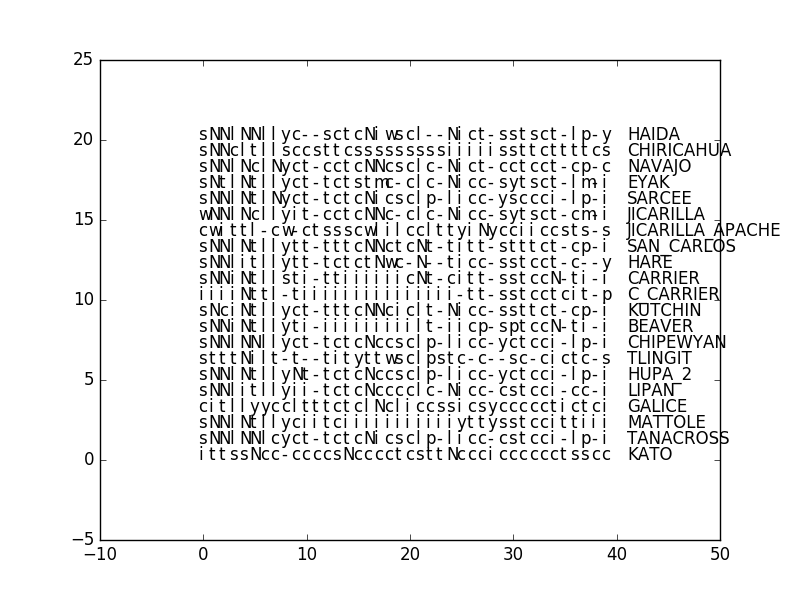

```python
Image(filename='Writeup\\GenCode.png')
```

# Markov chain monte carlo -

Draw from distribution of trees, parameters, and locations using Metropolis-Hastings algorithm. [(Baker, 2015)](http://www.stata-journal.com/article.html?article=st0354)

**Result: distribution over places and times - who was likely where, when?**

```python
HTML('''<html>
    <head>
    <title> MCMC Sampling of the Na-Dene language Tree with Locations </title>
    </head>
    <body>
    <video width="1200" height="800" controls="controls">
      <source src="SavedFigures\\CombNaDeneSim.mp4" type="video/mp4" />
    </video>
    </body>
</html>''')
```

[video not shown]

# Conclusions

1. Work in progress
2. Lots of fun with a great combination of reading, mathematics, programming, etc.
3. Still much to be done:
   - Catologuing Archaeological, Historical information - translating into Bayesian prior information.
   - Bells and whistles to the mathematical model

**And the original project - Galton's Problem!**

# If interested...

- Everything has been written up in an IPython notebook.
- You can find the slides for the talk and a bunch of other stuff at:

## https://github.com/mbaker21231/InstEvo

All code used to produce this talk is there.

# Constructive code

While this code will be hidden from view, we will keep it at the back of the document for ease of modification and integration.

```python
HTML('''<script>
code_show=true;
function code_toggle() {
 if (code_show){
 $('div.input').hide();
 } else {
 $('div.input').show();
 }
 code_show = !code_show
}
$( document ).ready(code_toggle);
</script>
<form action="javascript:code_toggle()"><input type="submit" value="Click here to toggle on/off the raw code."></form>''')
```